[figure not shown]

# Uber Eats - Do you want fries with that?

Team members:

- Agnieszka Kołomyjec
- Barbara Wierzba-Sowińska
- Krzysztof Łukjanowicz
- Marcin Sarnowski
- Natalia Skrzypczak

Conspect: Opening the new restaurant in the USA for our investor. Analizing the location and a profile of the restaurant based on the data.

- [Kaggle dataset](https://www.kaggle.com/datasets/ahmedshahriarsakib/uber-eats-usa-restaurants-menus)

### Data Description:

The data used for this project is a dataset on Uber Eats USA restaurants and menus, which was obtained from Kaggle. The dataset includes information on over 20,000 restaurants and menus, including their location, cuisine type, rating, and price range. Additionally, the dataset includes information on the individual dishes available at each restaurant, including their name, price, and description.

### Project Description

The goal of this project is to provide insights for an investor who wants to open a vegetarian restaurant in the USA. To achieve this, we analyzed the Uber Eats USA Restaurants Menus dataset from Kaggle, which contains information on various restaurants and their menus. The analysis focused on identifying the most popular vegetarian cuisines and dishes, as well as the top locations for vegetarian restaurants in the USA. The insights from this analysis can help the investor make informed decisions regarding the location and profile of their new vegetarian restaurant.

### Contents

- Presentation of the initial dataset data
- Presentation of the top 'vege' results
- How does it look like percentage-wise?
- The most popular...
- Conclusions

### Presentation of the initial dataset data

Top categories overall from Kaggle dataset

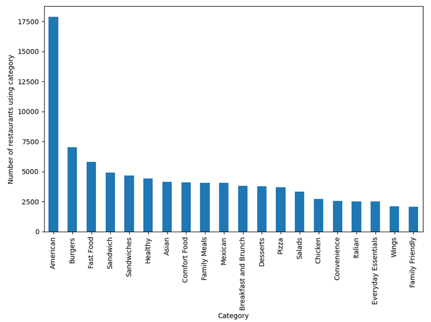

Top courses/drinks overall

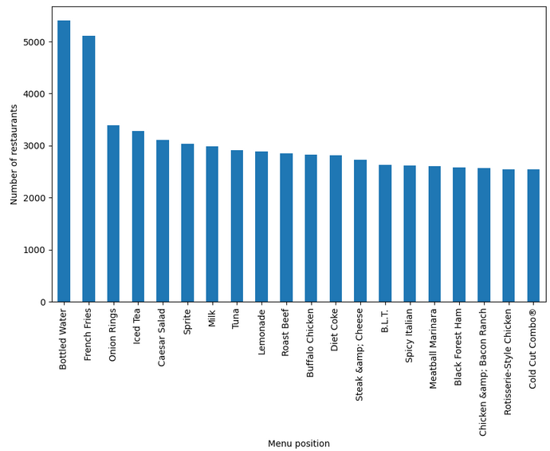

### Presentation of the top 'vege' results

Top vege restaurants categories

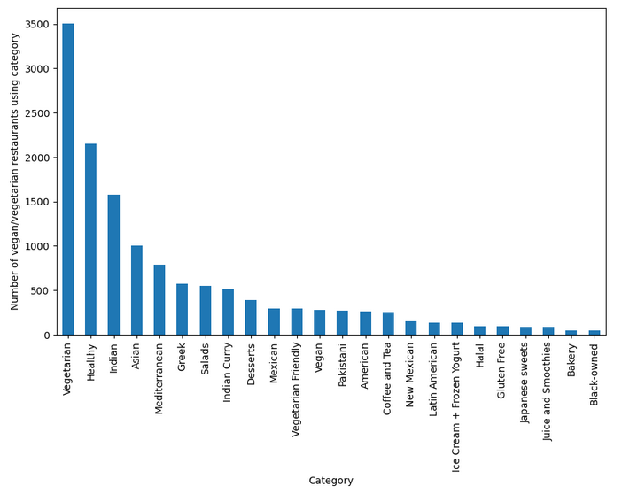

Top vege menus categories

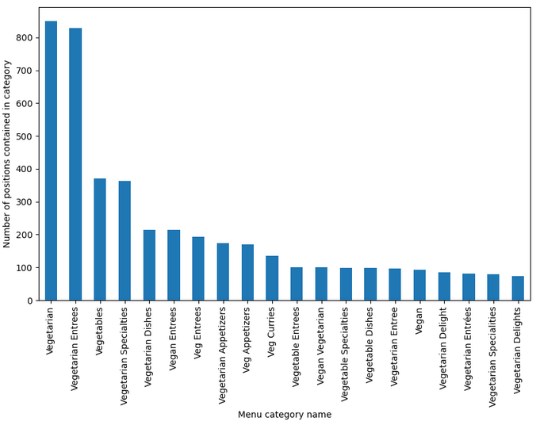

### How does it look like percentage-wise?

|  | state | cheap % | moderate % | expensive % | total |
| --- | --- | --- | --- | --- | --- |
| 0 | Alabama | 67.71 | 31.66 | 0.63 | 954.0 |
| 1 | District of Columbia | 70.56 | 27.08 | 2.36 | 1104.0 |
| 2 | Illinois | 76.63 | 23.37 | 0.00 | 184.0 |
| 3 | Maryland | 74.19 | 24.82 | 0.98 | 713.0 |
| 4 | Oregon | 82.23 | 17.21 | 0.56 | 709.0 |
| 5 | Puerto Rico | 91.19 | 8.81 | 0.00 | 159.0 |
| 6 | Texas | 71.22 | 28.44 | 0.34 | 5851.0 |
| 7 | Utah | 77.63 | 22.29 | 0.08 | 2566.0 |
| 8 | Vermont | 27.88 | 72.12 | 0.00 | 330.0 |
| 9 | Virginia | 80.50 | 18.94 | 0.56 | 8031.0 |
| 10 | Washington | 77.26 | 22.09 | 0.66 | 7316.0 |
| 11 | West Virginia | 54.63 | 45.22 | 0.15 | 1329.0 |
| 12 | Wisconsin | 57.62 | 42.20 | 0.18 | 3912.0 |
| 13 | Wyoming | 45.93 | 54.07 | 0.00 | 307.0 |

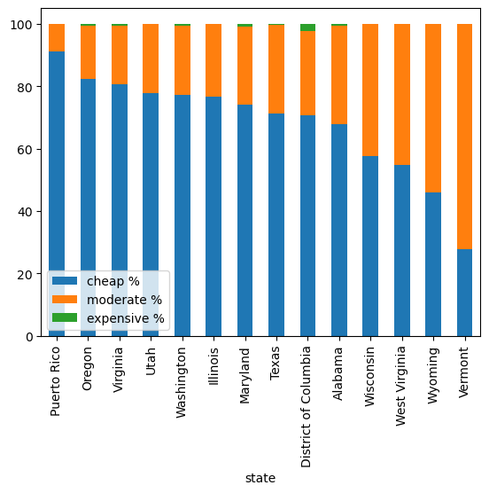

For an investor wanting to open a sustainable restaurant with healthy dishes in the USA, it would be really worth it to consider states, where there are many restaurants with "vege" options. It is widely known that plant food is both good for the environment and for our bodies. That's why such a restaurant MUST include vegetarian and vegan options.

| state | Total restaurants |
| --- | --- |
| Alabama | 1114 |
| District of Columbia | 1517 |
| Idaho | 27 |
| Illinois | 204 |
| Maryland | 897 |
| Minnesota | 43 |
| Ohio | 15 |
| Oregon | 1031 |
| Puerto Rico | 220 |
| Tennessee | 42 |
| Texas | 7322 |
| Utah | 3100 |
| Vermont | 351 |
| Virginia | 9341 |
| Washington | 8967 |
| West Virginia | 1381 |
| Wisconsin | 4335 |
| Wyoming | 320 |

How many restaurants are there with "vege" options in specific states percentage-wise?

|  | state | Total restaurants | Total restaurants with veg | veg restaurants % |
| --- | --- | --- | --- | --- |
| 0 | Alabama | 1114 | 69.0 | 6.19 |
| 1 | District of Columbia | 1517 | 183.0 | 12.06 |
| 2 | Idaho | 27 | 1.0 | 3.70 |
| 3 | Illinois | 204 | 9.0 | 4.41 |
| 4 | Maryland | 897 | 111.0 | 12.37 |
| 5 | Minnesota | 43 | 0.0 | 0.00 |
| 6 | Ohio | 15 | 0.0 | 0.00 |
| 7 | Oregon | 1031 | 121.0 | 11.74 |
| 8 | Puerto Rico | 220 | 11.0 | 5.00 |
| 9 | Tennessee | 42 | 1.0 | 2.38 |
| 10 | Texas | 7322 | 558.0 | 7.62 |
| 11 | Utah | 3100 | 219.0 | 7.06 |
| 12 | Vermont | 351 | 13.0 | 3.70 |
| 13 | Virginia | 9341 | 615.0 | 6.58 |
| 14 | Washington | 8967 | 955.0 | 10.65 |
| 15 | West Virginia | 1381 | 19.0 | 1.38 |
| 16 | Wisconsin | 4335 | 149.0 | 3.44 |
| 17 | Wyoming | 320 | 9.0 | 2.81 |

### The most popular...

What dishes are the most popular in vegetarian restaurants in the US?

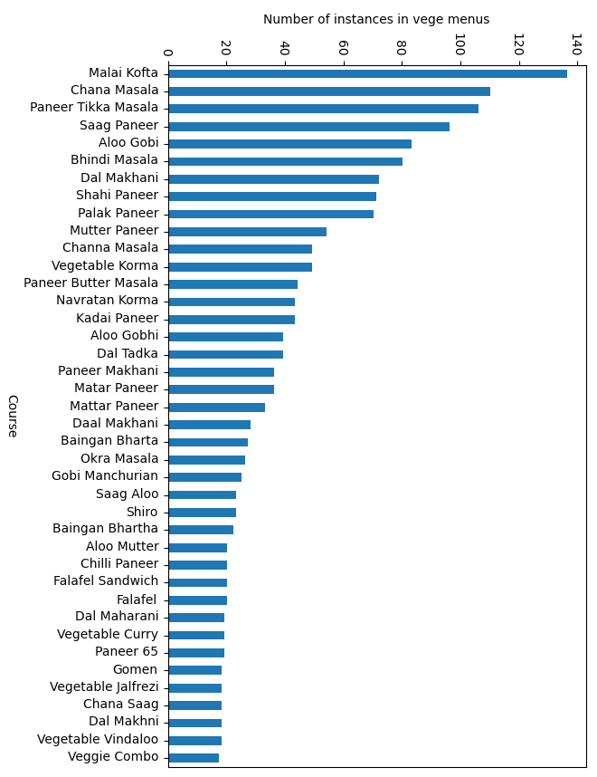

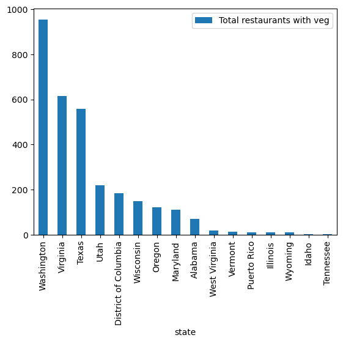

[figure not shown]

Are restaurants with "vege" options cheap or expensive? How does it look like percentage-wise?

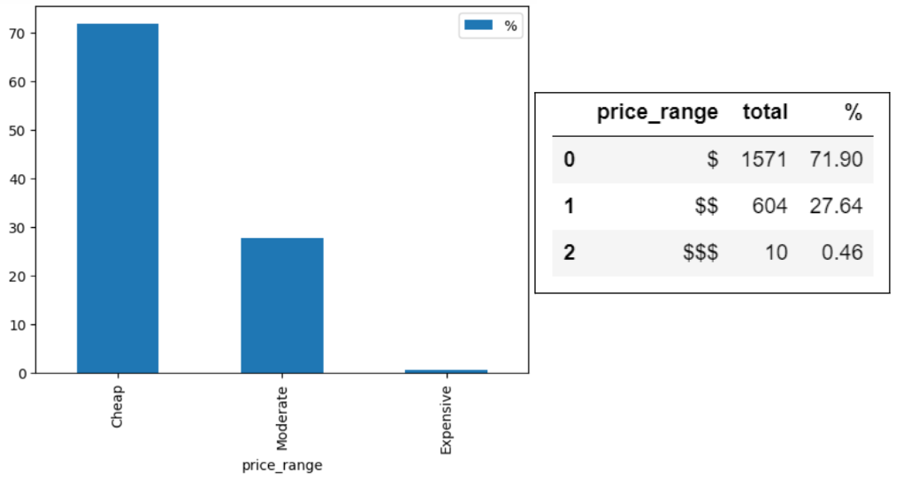

States with a considerable number of restaurants with plant-based options (over 10% of restaurants, states with at least 1000 records) are: District of Columbia (Washington DC, 12.06%), Oregon (11.74%), Washington (10.65%).

When in comes to prices, so there is a significant predominance of cheap restaurants. This is mostly caused by the fact that our data comprise of data from Uber eats, and people are in general not so eager to order takeaway from expensive restaurants.

It is worth noticing that when we compare prices in restaurants with vege options to the overall, the proportion of moderate restaurants to cheap restaurants is a little higher.

Top mean prices for vegan/vegetarian courses

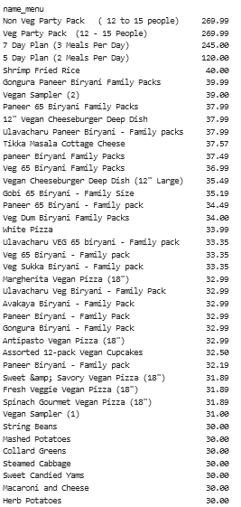

Restaurants scoring between 5.0 to 4.0

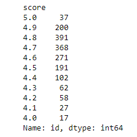

Conclusions: Vegetarian restaurants have relatively high ratings. Out of 1789 restaurants, 96 percent have a grade of 4.0 or higher, and 81 percent have a grade of 4.5 or higher."